# Case Study Unit 15 - Unlabeled Dataset Modeling and Prediction

Yao Yao, Ivelin Angelov, Brian Kruse

MSDS 7333 Section 402

August 20, 2018

## Introduction

An unlabeled dataset is applied ensemble categorical prediction methods to find the best accuracy and ROC score. Lesser features from random forest are removed and optimal parameters are found by gridsearch. Depending on customer needs, ROC score, accuracy, precision, recall, and F1-Score are all calculated as metrics to focus on true positive over false positive rate, correct predictions, true positives, false negatives, or the balance between true positives and false negatives. For the purposes of this study, ROC score and precision are used.

## Methods

The steps used for this analysis were: data exploration, conversion of categorical data into dummy numerical variables, filling in missing values with the mean, application of categorical prediction, removal of lesser features, random forest parameter gridsearch, and finding the model with best ROC score, accuracy, precision, recall, and F1-Score.

```python
import sys
try:
    sys.getwindowsversion()
except AttributeError:
    isWindows = False
else:
    isWindows = True
if isWindows:
    import win32api,win32process,win32con
    pid = win32api.GetCurrentProcessId()
    handle = win32api.OpenProcess(win32con.PROCESS_ALL_ACCESS, True, pid)
    win32process.SetPriorityClass(handle, win32process.HIGH_PRIORITY_CLASS)
import warnings
warnings.filterwarnings('ignore')

import pandas as pd
import numpy as np
import seaborn as sns
import matplotlib.pyplot as plt
from sklearn import cross_validation
from sklearn.cross_validation import train_test_split
from sklearn.ensemble import RandomForestClassifier
from sklearn.grid_search import GridSearchCV, RandomizedSearchCV
from sklearn.linear_model import LogisticRegression
from sklearn.metrics import accuracy_score, classification_report, confusion_matrix, roc_auc_score, roc_curve
from sklearn.tree import DecisionTreeClassifier
from sklearn.preprocessing import MinMaxScaler
from sklearn import metrics

%matplotlib inline
```

## Results

```python
df=pd.read_csv("final_project.csv")
print("Table 1: Summary of Values")
df.describe()
```

```
Table 1: Summary of Values
```

|  | x0 | x1 | x2 | x3 | x4 | x5 | x6 | x7 | x8 | x9 | ... | x41 | x42 | x43 | x44 | x45 | x46 | x47 | x48 | x49 | y |
| --- | --- | --- | --- | --- | --- | --- | --- | --- | --- | --- | --- | --- | --- | --- | --- | --- | --- | --- | --- | --- | --- |
| count | 159974.000000 | 159975.000000 | 159962.000000 | 159963.000000 | 159974.000000 | 159963.000000 | 159974.000000 | 159973.000000 | 159979.000000 | 159970.000000 | ... | 159960.000000 | 159974.000000 | 159963.000000 | 159960.000000 | 159971.000000 | 159969.000000 | 159963.000000 | 159968.000000 | 159968.000000 | 160000.000000 |
| mean | -0.001028 | 0.001358 | -1.150145 | -0.024637 | -0.000549 | 0.013582 | -1.670670 | -7.692795 | -0.030540 | 0.005462 | ... | 6.701076 | -1.833820 | -0.002091 | -0.006250 | 0.000885 | -12.755395 | 0.028622 | -0.000224 | -0.674224 | 0.401231 |
| std | 0.371137 | 6.340632 | 13.273480 | 8.065032 | 6.382293 | 7.670076 | 19.298665 | 30.542264 | 8.901185 | 6.355040 | ... | 18.680196 | 5.110705 | 1.534952 | 4.164595 | 0.396621 | 36.608641 | 4.788157 | 1.935501 | 15.036738 | 0.490149 |
| min | -1.592635 | -26.278302 | -59.394048 | -35.476594 | -28.467536 | -33.822988 | -86.354483 | -181.506976 | -37.691045 | -27.980659 | ... | -82.167224 | -27.933750 | -6.876234 | -17.983487 | -1.753221 | -201.826828 | -21.086333 | -8.490155 | -65.791191 | 0.000000 |
| 25% | -0.251641 | -4.260973 | -10.166536 | -5.454438 | -4.313118 | -5.148130 | -14.780146 | -27.324771 | -6.031058 | -4.260619 | ... | -5.804080 | -5.162869 | -1.039677 | -2.812055 | -0.266518 | -36.428329 | -3.216016 | -1.320800 | -10.931753 | 0.000000 |
| 50% | -0.002047 | 0.004813 | -1.340932 | -0.031408 | 0.000857 | 0.014118 | -1.948594 | -6.956789 | -0.016840 | 0.006045 | ... | 6.840110 | -1.923754 | -0.004385 | -0.010484 | 0.001645 | -12.982497 | 0.035865 | -0.011993 | -0.574410 | 0.000000 |
| 75% | 0.248532 | 4.284220 | 7.871676 | 5.445179 | 4.306660 | 5.190749 | 11.446931 | 12.217071 | 5.972349 | 4.305734 | ... | 19.266367 | 1.453507 | 1.033275 | 2.783274 | 0.269049 | 11.445443 | 3.268028 | 1.317703 | 9.651072 | 1.000000 |
| max | 1.600849 | 27.988178 | 63.545653 | 38.906025 | 26.247812 | 35.550110 | 92.390605 | 149.150634 | 39.049831 | 27.377842 | ... | 100.050432 | 22.668041 | 6.680922 | 19.069759 | 1.669205 | 150.859415 | 20.836854 | 8.226552 | 66.877604 | 1.000000 |

8 rows × 46 columns

The dataset has 1608 (~1%) rows where any of the variables are missing [Table 2]. For some prediction methods, those rows with at least one missing variable are removed from the training and prediction. To use all the data for training and prediction, missing values are filled with the column mean.

```python
df.isnull().T.any().T.sum()
```

```
1608
```

```python
nan_rows = df[df.isnull().T.any().T]
print("Table 2: Summary of Missing Values")
nan_rows.describe()
```

```
Table 2: Summary of Missing Values
```

|  | x0 | x1 | x2 | x3 | x4 | x5 | x6 | x7 | x8 | x9 | ... | x41 | x42 | x43 | x44 | x45 | x46 | x47 | x48 | x49 | y |
| --- | --- | --- | --- | --- | --- | --- | --- | --- | --- | --- | --- | --- | --- | --- | --- | --- | --- | --- | --- | --- | --- |
| count | 1582.000000 | 1583.000000 | 1570.000000 | 1571.000000 | 1582.000000 | 1571.000000 | 1582.000000 | 1581.000000 | 1587.000000 | 1578.000000 | ... | 1568.000000 | 1582.000000 | 1571.000000 | 1568.000000 | 1579.000000 | 1577.000000 | 1571.000000 | 1576.000000 | 1576.000000 | 1608.000000 |
| mean | -0.023089 | -0.233420 | -1.334860 | -0.188496 | -0.028848 | 0.043772 | -1.781634 | -7.183631 | -0.198952 | 0.120118 | ... | 6.200587 | -1.919930 | 0.006288 | 0.095173 | -0.010298 | -13.097050 | 0.064960 | -0.038781 | -0.892512 | 0.404851 |
| std | 0.377887 | 6.371781 | 13.148857 | 7.903637 | 6.281941 | 7.465302 | 19.122589 | 30.617878 | 8.611786 | 6.423960 | ... | 19.134098 | 5.173962 | 1.501816 | 4.247622 | 0.398343 | 36.619341 | 4.807995 | 1.976918 | 15.397989 | 0.491016 |
| min | -1.212433 | -20.786128 | -46.839020 | -35.476594 | -19.843832 | -22.177503 | -68.100416 | -114.772305 | -28.924057 | -20.818082 | ... | -56.737666 | -21.803655 | -4.542599 | -15.753439 | -1.454419 | -163.129051 | -15.862626 | -6.787061 | -54.694111 | 0.000000 |
| 25% | -0.285652 | -4.369415 | -10.143075 | -5.602259 | -4.257341 | -4.962307 | -14.582127 | -27.591361 | -5.802014 | -4.272139 | ... | -6.106080 | -5.344361 | -0.986784 | -2.691970 | -0.275705 | -35.700450 | -3.143514 | -1.321321 | -11.295675 | 0.000000 |
| 50% | -0.025781 | -0.485559 | -1.277619 | -0.194008 | 0.231269 | -0.089206 | -1.705497 | -6.450030 | -0.112694 | 0.308101 | ... | 5.706609 | -2.111798 | -0.010264 | 0.143722 | -0.013758 | -13.589745 | -0.008036 | -0.048894 | -1.103583 | 0.000000 |
| 75% | 0.240336 | 3.983232 | 6.859011 | 5.098055 | 4.124178 | 5.052989 | 10.072974 | 12.546484 | 5.507070 | 4.530010 | ... | 18.694504 | 1.563673 | 0.979456 | 2.964701 | 0.252075 | 11.418635 | 3.106903 | 1.277409 | 9.689655 | 1.000000 |
| max | 1.062456 | 20.880954 | 49.259277 | 23.203595 | 23.226720 | 26.222837 | 71.619288 | 91.092993 | 28.870563 | 20.682787 | ... | 71.738214 | 16.080077 | 4.753253 | 11.829855 | 1.606014 | 95.250240 | 15.429290 | 7.365519 | 56.297506 | 1.000000 |

8 rows × 46 columns

Of the categorical variables, percentages and dollar values can be converted into numerical by removing their respective symbols [Table 3].

```python
print("Table 3: Summary of Categorical Values")
df[df.columns[df.dtypes == "O"]].describe()
```

```
Table 3: Summary of Categorical Values
```

|  | x24 | x29 | x30 | x32 | x37 |
| --- | --- | --- | --- | --- | --- |
| count | 159972 | 159970 | 159970 | 159969 | 159977 |
| unique | 3 | 12 | 5 | 12 | 129198 |
| top | asia | July | wednesday | 0.01% | $618.22 |
| freq | 138965 | 45569 | 101535 | 40767 | 6 |

```python
df.x32 = df.x32.str.replace('%', '').astype(np.float32)
df.x37 = df.x37.str.replace('$', '').astype(np.float32)
```

```python
colnames=list(df.drop(['y'], axis=1).select_dtypes(exclude='O').columns.values)
df[colnames] = df[colnames].astype(np.float32)
df['y'] = df['y'].astype(np.int32)
```

#### Distribution of variables by label

Figure 1 to 47 show that the numerical variables have normal distributions where some show separation of data by label while others show no difference.

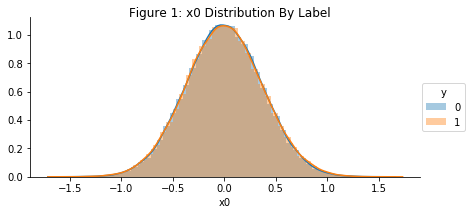

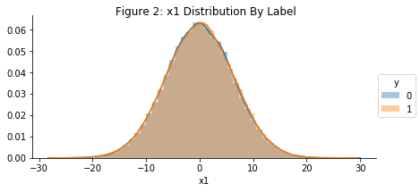

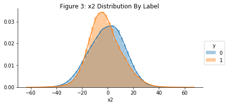

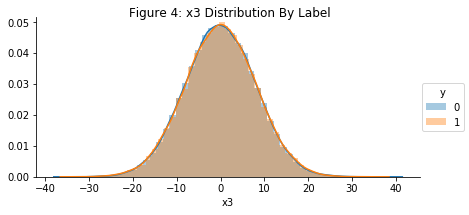

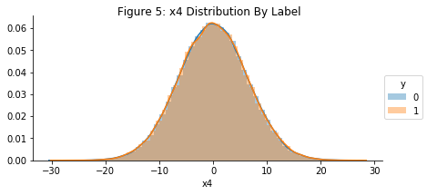

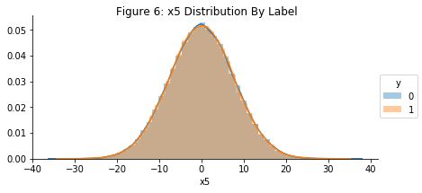

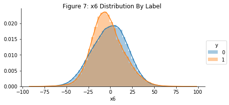

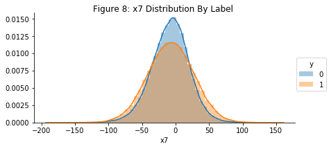

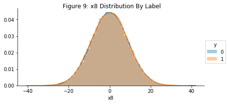

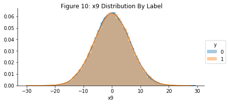

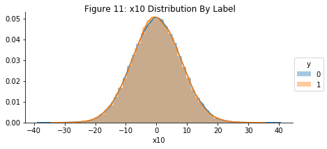

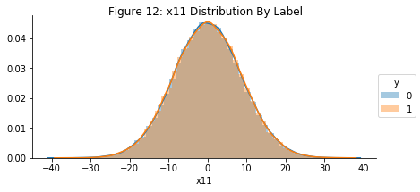

[35 more figures not shown]

```python
plt.rcParams['figure.max_open_warning']=40
colnames=list(df.drop(['y'], axis=1).select_dtypes(exclude='O').columns.values)
for i in colnames[0:]:
    facet = sns.FacetGrid(df, hue='y',aspect=2)
    facet.map(sns.distplot,i)
    facet.add_legend()
    facet.fig.suptitle(''.join(map(str, list(["Figure ",colnames.index(i)+1,": ",i," Distribution By Label"]))))
    plt.show()
```

#### Figure 1 to 47: Numerical variables have normal distributions where some show separation of data by label while others show no difference.

The three categorical variables plotted by label show that some have larger separation than that for others [Figure 48 to 50].

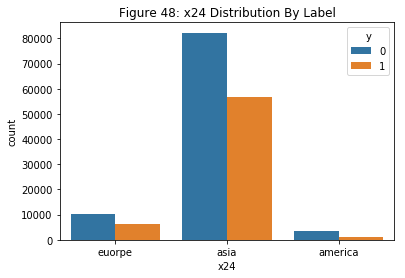

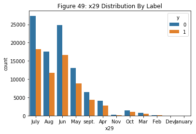

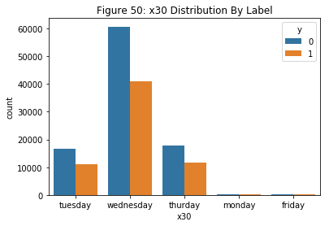

```python
plt.rcParams['figure.max_open_warning']=40
colnames=list(df.select_dtypes(include='O').columns.values)
for i in colnames[0:]:
    ax = plt.axes()
    sns.countplot(x=i, data=df, hue="y", ax = ax)
    ax.set_title(''.join(map(str, list(["Figure ",colnames.index(i)+48,": ",i," Distribution By Label"]))))
    plt.show()
```

#### Figure 48 to 50: The three categorical variables plotted by label show that some have larger separation than that for others

```python
# df['x24'].loc[df['x24'] == 'asia'] = 1
# df['x24'].loc[df['x24'] == 'euorpe'] = 2
# df['x24'].loc[df['x24'] == 'america'] = 3

# df['x29'].loc[df['x29'] == 'January'] = 1
# df['x29'].loc[df['x29'] == 'Feb'] = 2
# df['x29'].loc[df['x29'] == 'Mar'] = 3
# df['x29'].loc[df['x29'] == 'Apr'] = 4
# df['x29'].loc[df['x29'] == 'May'] = 5
# df['x29'].loc[df['x29'] == 'Jun'] = 6
# df['x29'].loc[df['x29'] == 'July'] = 7
# df['x29'].loc[df['x29'] == 'Aug'] = 8
# df['x29'].loc[df['x29'] == 'sept.'] = 9
# df['x29'].loc[df['x29'] == 'Oct'] = 10
# df['x29'].loc[df['x29'] == 'Nov'] = 11
# df['x29'].loc[df['x29'] == 'Dev'] = 12

# df['x30'].loc[df['x30'] == 'monday'] = 1
# df['x30'].loc[df['x30'] == 'tuesday'] = 2
# df['x30'].loc[df['x30'] == 'wednesday'] = 3
# df['x30'].loc[df['x30'] == 'thurday'] = 4
# df['x30'].loc[df['x30'] == 'friday'] = 5

# df[colnames].describe()
```

```python
# df[colnames] = df[colnames].astype(np.float32)
# for i in colnames[0:]:
#     facet = sns.FacetGrid(df, hue='y',aspect=2)
#     facet.map(sns.distplot,i)
#     facet.add_legend()
#     plt.show()
```

```python
colnames=list(df.drop(['y'], axis=1).select_dtypes(exclude='O').columns.values)
for i in colnames[0:]:
    if pd.notnull(i):
        mean = df[i].mean()
        df[i] = df[i].fillna(mean)
```

```python
colnames=list(df.select_dtypes(include='O').columns.values)
for i in colnames[0:]:
    # Fill missing data with the word "Missing"
    df[i].fillna("Missing", inplace=True)
    # Create array of dummies
    dummies = pd.get_dummies(df[i], prefix=i)
    # Update X to include dummies and drop the main variable
    df = pd.concat([df, dummies], axis=1)
    df.drop([i], axis=1, inplace=True)
```

After filling the missing values with their respective column means and converting categorical values to dummy variables, the correlation heatmap of the variables show slight colinearity [Figure 51].

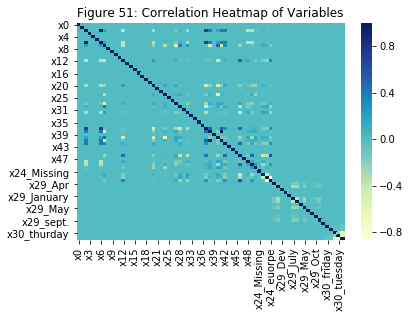

```python
ax = plt.axes()
sns.heatmap(df.corr(), cmap="YlGnBu", ax = ax)
ax.set_title('Figure 51: Correlation Heatmap of Variables')
plt.show()
```

#### Figure 51: The correlation heatmap of the variables show slight colinearity

### Predictions

The dataset is scaled from 1 to 0 so that the later removal of lesser features are not influenced by the numeric range of the variables. The training and test set are separated with a 4:1 ratio with random state of 2. The get_metrics function finds the ROC score, accruacy, precision, recall, and F1 Score.

```python
y = df.pop('y')

columns = df.columns
sc = MinMaxScaler(feature_range=(0, 1))
df = sc.fit_transform(df)
df = pd.DataFrame(df, columns=columns)

x_train, x_test, y_train, y_test = train_test_split(df, y, test_size=0.2, random_state=2)

def get_metrics(y_true, y_pred, treshhold=.5):
    y_pred = (y_pred > treshhold).astype(np.int32)
    return dict(
        RocAuc="{:.4f}".format(metrics.roc_auc_score(y_test, y_pred)),
        Accuracy="{:.4f}".format(metrics.accuracy_score(y_test, y_pred)),
        Precision="{:.4f}".format(metrics.precision_score(y_test, y_pred)),
        Recall="{:.4f}".format(metrics.recall_score(y_test, y_pred)),
        F1="{:.4f}".format(metrics.f1_score(y_test, y_pred))
    )
```

With binary classification, logistic regression, decision tree classifier, and random forest classifier are selected. Logistic regression has a ROC score of 0.67 and a precision of 0.67; decision tree classifier has a ROC score of 0.84 and a precision of 0.81; random forest classifier has a ROC score of 0.87 and a precision of 0.92. Accuracy, recall, and F1-Score metrics also are calculated.

```python
model1 = LogisticRegression()
model1.fit(x_train, y_train)
print("Test Dataset :", get_metrics(y_test, model1.predict(x_test)))
```

```
Test Dataset : {'RocAuc': '0.6730', 'Accuracy': '0.7032', 'Precision': '0.6697', 'Recall': '0.5184', 'F1': '0.5844'}
```

```python
model2 = DecisionTreeClassifier()
model2.fit(x_train, y_train)
print("Test Dataset :", get_metrics(y_test, model2.predict(x_test)))
```

```
Test Dataset : {'RocAuc': '0.8392', 'Accuracy': '0.8453', 'Precision': '0.8076', 'Recall': '0.8082', 'F1': '0.8079'}
```

```python
model3 = RandomForestClassifier(n_jobs=-1)
model3.fit(x_train, y_train)
print("Test Dataset :", get_metrics(y_test, model3.predict(x_test)))
```

```
Test Dataset : {'RocAuc': '0.8756', 'Accuracy': '0.8910', 'Precision': '0.9221', 'Recall': '0.7966', 'F1': '0.8547'}
```

Since random forest classifier performed the best, the number of estimators are increased for a higher ROC score of 0.91 and a precision of 0.93. Accuracy, recall, and F1-Score metrics also are calculated. The features that most affect the model are above 0.01 [Figure 52].

```python
model4 = RandomForestClassifier(n_estimators=100, oob_score=True,n_jobs=-1, random_state=2)
model4.fit(x_train, y_train)
print("Test Dataset :", get_metrics(y_test, model4.predict(x_test)))
```

```
Test Dataset : {'RocAuc': '0.9145', 'Accuracy': '0.9232', 'Precision': '0.9348', 'Recall': '0.8700', 'F1': '0.9012'}
```

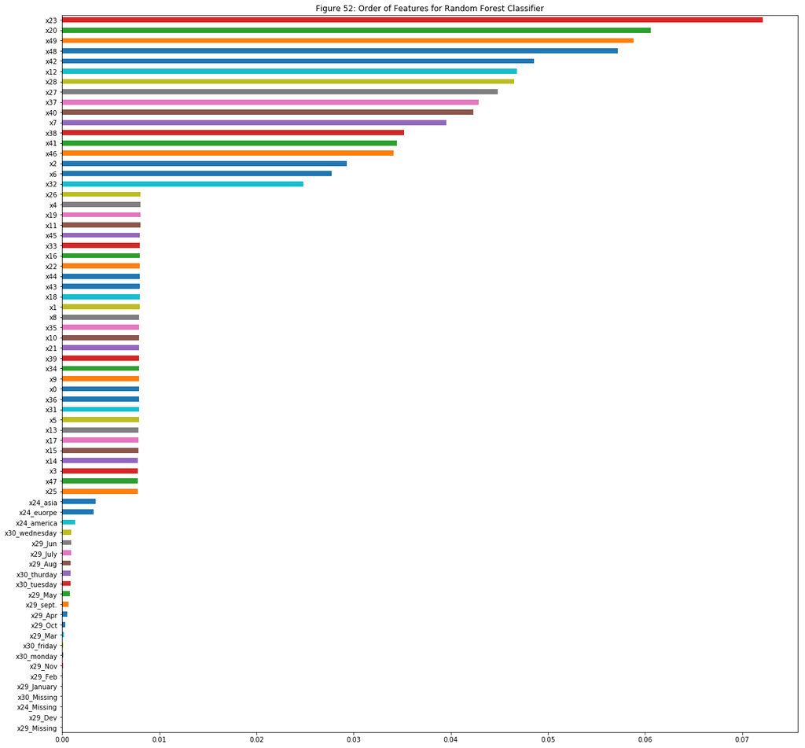

```python
feature_importances = pd.Series(model4.feature_importances_, index=df.columns)
feature_importances.sort_values().plot(kind="barh", figsize=(20,20),
                                       title = "Figure 52: Order of Features for Random Forest Classifier");
```

#### Figure 52: The features that most affect the model are 0.01 and above

### Drop lesser features

The features that are 0.01 and below are removed from the dataset because there is overfitting of the training and testing data for the prediction process [Table 4].

```python
print("Table 4: Lesser Features of Random Forest Classifier")
feature_importances.sort_values()[:53]
```

```
Table 4: Lesser Features of Random Forest Classifier
```

```
x29_Missing      0.000004
x29_Dev          0.000006
x24_Missing      0.000006
x30_Missing      0.000008
x29_January      0.000014
x29_Feb          0.000032
x29_Nov          0.000087
x30_monday       0.000109
x30_friday       0.000125
x29_Mar          0.000211
x29_Oct          0.000334
x29_Apr          0.000532
x29_sept.        0.000623
x29_May          0.000777
x30_tuesday      0.000837
x30_thurday      0.000853
x29_Aug          0.000865
x29_July         0.000913
x29_Jun          0.000947
x30_wednesday    0.000952
x24_america      0.001331
x24_euorpe       0.003221
x24_asia         0.003459
x25              0.007758
x47              0.007779
x3               0.007787
x14              0.007811
x15              0.007829
x17              0.007867
x13              0.007883
x5               0.007896
x31              0.007901
x36              0.007906
x0               0.007909
x9               0.007911
x34              0.007912
x39              0.007919
x21              0.007930
x10              0.007945
x35              0.007947
x8               0.007952
x1               0.007961
x18              0.007964
x43              0.007966
x44              0.007968
x22              0.007974
x16              0.007979
x33              0.007994
x45              0.007994
x11              0.008024
x19              0.008045
x4               0.008063
x26              0.008065
dtype: float64
```

#### Table 4: The features that are 0.01 and below are removed from the data because there is overfitting of the training and testing data for prediction

```python
x_test.drop(feature_importances.sort_values()[:53].index, axis=1, inplace=True)
x_train.drop(feature_importances.sort_values()[:53].index, axis=1, inplace=True)
df.drop(feature_importances.sort_values()[:53].index, axis=1, inplace=True)
```

Once the lesser features are removed, the ROC score increased to 0.94 and precision increased to 0.95.

```python
model = RandomForestClassifier(n_estimators=100, oob_score=True,n_jobs=-1, random_state=2)
model.fit(x_train, y_train)
print("Test Dataset :", get_metrics(y_test, model.predict(x_test)))
```

```
Test Dataset : {'RocAuc': '0.9358', 'Accuracy': '0.9414', 'Precision': '0.9455', 'Recall': '0.9069', 'F1': '0.9258'}
```

A randomized search of min samples split, max features, and criterion is performed to find the best hyperparameters. The best hyperparameters show that min samples split is 3, max features is log2, and criterion is entropy.

```python
# Performing RandomizedSearch to tune the hyperparameters for the RF Classifier
hyperparameters = {'min_samples_split': [2,3,4],
                   'max_features': ['auto', 'sqrt', 'log2'],
                   'criterion': ['entropy', 'gini'],
                  }
rfc = RandomForestClassifier(n_jobs=-1, random_state=2, n_estimators=200)

search =  RandomizedSearchCV(rfc, hyperparameters, cv=5, scoring='roc_auc')
# Training the model
search.fit(x_train, y_train)
# Best parameters to use to build the final model
best_rfc = search.best_estimator_
best_rfc
```

```
RandomForestClassifier(bootstrap=True, class_weight=None, criterion='entropy',
            max_depth=None, max_features='log2', max_leaf_nodes=None,
            min_impurity_decrease=0.0, min_impurity_split=None,
            min_samples_leaf=1, min_samples_split=3,
            min_weight_fraction_leaf=0.0, n_estimators=200, n_jobs=-1,
            oob_score=False, random_state=2, verbose=0, warm_start=False)
```

```python
# Generating AUC score using the best model
best_rfc.fit(x_train, y_train)
print("Test Dataset :", get_metrics(y_test, best_rfc.predict(x_test)))
```

```
Test Dataset : {'RocAuc': '0.9383', 'Accuracy': '0.9433', 'Precision': '0.9441', 'Recall': '0.9131', 'F1': '0.9283'}
```

Using the predict_proba instead of predict function, the ROC area under the curve score is 0.98 [Figure 53].

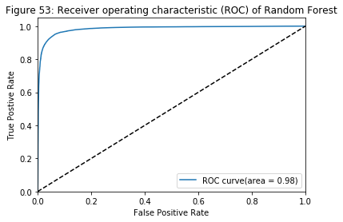

```python
# Visualizing -> Area Under the Curve (AUC) for the best model
fpr, tpr, thresholds = roc_curve(y_test, best_rfc.predict_proba(x_test)[:,1])

plt.figure()
plt.plot(fpr, tpr, label='ROC curve(area = %0.2f)' %roc_auc_score(y_test, best_rfc.predict_proba(x_test)[:,1]))
plt.plot([0,1], [0,1], 'k--')
plt.xlim([0.0, 1.0])
plt.ylim([0.0, 1.05])
plt.xlabel('False Positive Rate')
plt.ylabel('True Postive Rate')
plt.title('Figure 53: Receiver operating characteristic (ROC) of Random Forest')
plt.legend(loc='lower right')
plt.show()
```

#### Figure 53: Using the predict_proba instead of predict function, the ROC area under the curve score is 0.98

Increasing the number of estimators to 1000 slightly increased both ROC score and precision slightly.

```python
# Building the final RF Classifier model with the best parameters

rfc = RandomForestClassifier(criterion='entropy',
                               n_estimators=1000,
                               n_jobs=-1,
                               random_state=2,
                               max_features='log2',
                               min_samples_split=3)
rfc.fit(x_train, y_train)
#roc = roc_auc_score(y_test, rfc.predict_proba(x_test)[:,1])
print("Test Dataset :", get_metrics(y_test, rfc.predict(x_test)))
```

```
Test Dataset : {'RocAuc': '0.9390', 'Accuracy': '0.9440', 'Precision': '0.9457', 'Recall': '0.9134', 'F1': '0.9293'}
```

The order of important features for the random forest classifier shows 17 numerical variables contributing to the prediction model [Figure 54].

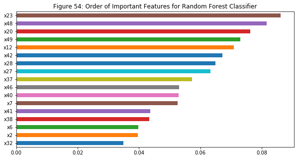

```python
featureimportance = pd.Series(rfc.feature_importances_, index=df.columns)
featureimportance.sort_values().plot(kind='barh', figsize=(10,5),
                                                 title = "Figure 54: Order of Important Features for Random Forest Classifier");
```

#### Figure 54: The order of important features for the random forest classifier shows 17 numerical variables contributing to the prediction model

## Conclusion

Depending on customer needs, ROC score, accuracy, precision, recall, and F1-Score are all calculated as metrics to focus on correct predictions, true positives, false negatives, or the balance between true positives and false negatives. For the best binary predictor, random forest with min samples split as 3, max features as log2, and criterion as entropy are the best hyperparameters. The removal of lesser features reduced overfitting and increased the ROC score and accuracy of the prediction. Setting the number of estimators as 1000 further increased the final metrics, where ROC score is 0.9390, accuracy is 0.9440, precision is 0.9457, recall is 0.9134, and F1-score is 0.9293. Further information from the original dataset is needed for which metric emphasis is needed to tune the parameters to satisfy customer needs.